# Robust regression for noisy biological data

Jaron Arbet

9/2/24

## Motivation

- Ordinal or numeric outcome (continuous or discrete)
- May have outliers or non-normally distributed  
  (*e.g.* skewed, heavy tails)
- Examples in our lab:
  - Normalized RNA or protein abundance
  - Copy Number
  - DNA methylation beta or m-values
- **Goal**: Perform robust statistical tests comparing noisy features btwn groups, potentially adjusting for covariates
- **Robust**?
  - Minimal assumptions on the data distribution
  - Control false-positive-rate for wide variety of data-types
  - Insensitive to outliers

## But first… the Wilcoxon/Mann-Whitney U-test

- Ordinal/numeric outcome btwn 2 unpaired groups
- Robust to outliers and no assumptions on data distribution
- **Example**:
  - NHANES diabetes data ([source](https://hbiostat.org/data/))
  - Compare HbA1c between 914 patients diagnosed with diabetes (or pre-diabetes) *vs.* 5881 undiagnosed

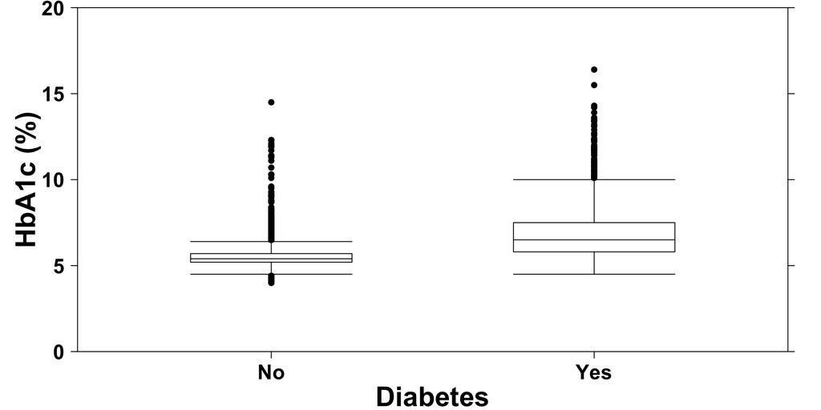

### Questions:

1. What is the Null and Alternative hypothesis?
2. What is the effect size?

## How it works

- Analyze ranked *order* of the data, rather than raw values:
1. Combine the 2 groups and rank from smallest to largest:

Example of 8 patients

| diabetes | HbA1c | rank |
| --- | --- | --- |
| No | 5.4 | 1.0 |
| No | 5.6 | 2.0 |
| Yes | 5.8 | 3.5 |
| No | 5.8 | 3.5 |
| Yes | 6.4 | 5.0 |
| Yes | 6.9 | 6.0 |
| No | 7.0 | 7.0 |
| Yes | 9.3 | 8.0 |

2. Wilcoxon test statistic:

$$\begin{equation}
W = R^*_1 - \frac{n_1(n_1 + 1)}{2}
\end{equation}$$

- $R^*_1$ = sum of ranks in group 1
- $n_1$ = sample size in group 1

Wilcoxon test using the full data:

```r
wilcox <- wilcox.test(
    formula = HbA1c ~ diabetes,
    data = nhgh
    );
wilcox$statistic;
```

```
       W
754851.5
```

```r
wilcox$p.value;
```

```
[1] 4.413508e-270
```

- Notice $W=$ 754851.5, which we can manually verify:

```r
nhgh$rank <- rank(nhgh$HbA1c);
sum.ranks.group.1 <- sum(nhgh$rank[nhgh$diabetes == 'No']);
n1 <- sum(nhgh$diabetes == 'No');
sum.ranks.group.1 - n1*(n1 + 1) / 2
```

```
[1] 754851.5
```

## Hypothesis test

- **Null**: The 2 distributions are the same
- **Alt**: The 2 distributions differ, *i.e.* one distribution tends to produce larger/smaller values than the other.

Notice that is much more general compared to the t-test:

- **Null**: Both groups have the same mean
- **Alt:** Both groups have different means
- Exact and asymptotic distributions of $W$ were derived and can be used to calculate p-value<sup>1</sup>

1. https://www.stat.auckland.ac.nz/~wild/ChanceEnc/Ch10.wilcoxon.pdf

## Effect size

- Often people only report the p-value, software is inconsistent on what effect size is reported
- **c-index**<sup>1</sup> (concordance probability, probability index):
  - $c = Pr (Y_2 > Y_1)$ probability that value in group 2 is larger than group 1
  - Null $c = 0.5$
  - For a continuous variable $c$ = AUROC

1. https://hbiostat.org/bbr/nonpar#two-sample-test-wilcoxonmannwhitney

## Diabetes example

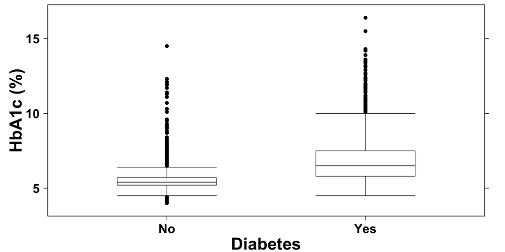

```r
wilcox <- asht::wmwTest(
    formula = HbA1c ~ diabetes,
    data = nhgh
    );
sprintf('c-index = %s', as.numeric(round(wilcox$estimate, 2)));
```

```
[1] "c-index = 0.86"
```

```r
round(wilcox$conf.int, 2);
```

```
[1] 0.85 0.87
attr(,"conf.level")
[1] 0.95
```

```r
wilcox$p.value;
```

```
[1] 4.413508e-270
```

There is a 0.86 probability that diabetes patients have higher HbA1c compared to undiagnosed patients.

## Wilcoxon *vs.* other methods

- Table<sup>1</sup> below compares power of t-test *vs.* Wilcoxon
- Values > 1 mean Wilcoxon is more powerful

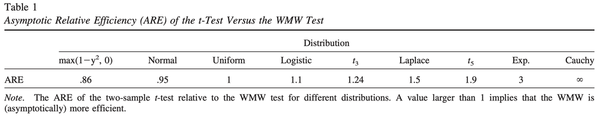

- Wilcoxon better controls FPR compared to DESeq2, edgeR, limma-voom, NOISeq, dearseq(Li et al. 2022)
  - Recommends n $\ge$ 8 per group<sup>2</sup>
- <sup>1</sup>De Schryver, Maarten, and Jan De Neve. “A tutorial on probabilistic index models: Regression models for the effect size P (Y1< Y2).” Psychological Methods 24.4 (2019): 403.
- <sup>2</sup>https://towardsdatascience.com/deseq2-and-edger-should-no-longer-be-the-default-choice-for-large-sample-differential-gene-8fdf008deae9

## Adjusting Wilcoxon test for covariates

- Most people mistakenly think Wilcoxon test and similar rank-based methods can’t adjust for covariates, however:
- The Wilcoxon test statistic $W$ is equivalent to the score test statistic from a **proportional odds (PO) regression model**<sup>1-3</sup>
- Thus the PO model can be used to perform Wilcoxon-like tests while adjusting for covariates.
- <sup>1</sup>McCullagh, Peter. “Regression models for ordinal data.” Journal of the Royal Statistical Society: Series B (Methodological) 42.2 (1980): 109-127.
- <sup>2</sup>[Equivalence of Wilcoxon Statistic and Proportional Odds Model](https://www.fharrell.com/post/powilcoxon/)
- <sup>3</sup>If You Like the Wilcoxon Test You Must Like the Proportional Odds Model

## Proportional Odds (PO) Model

- Also called ordered logit or ordinal logistic regression

Let $Y = 1, 2, ..., k$ be the *k* unique values of *Y*:

$$\begin{equation}
Pr(Y \ge j | X) = \frac{1}{1 + exp[-(\alpha_j + X\beta)]} = expit(\alpha_j + X\beta)
\end{equation}$$

- $j = 1,2, ..., k - 1$
- $\alpha_j$ is the logit of $Pr(Y \ge j | X = 0)$

https://hbiostat.org/rmsc/ordinal

## Interpretation of $\beta$:

$$\begin{equation}
exp(\beta) = \frac{\text{Odds } Y \ge j | X = x + 1}{\text{Odds } Y \ge j | X = x}
\end{equation}$$

- “odds of having larger value of $Y$ given 1 unit increase in $X$”
- “Group A has __ times greater odds of having a larger $Y$ compared to group B”
- Parameters $\beta, \alpha_j$ estimated using MLE or Bayesian methods

## “Proportional odds”?

- $\beta$ is constant for all values of $Y$. Similar to CoxPH model where HR is constant for all time.

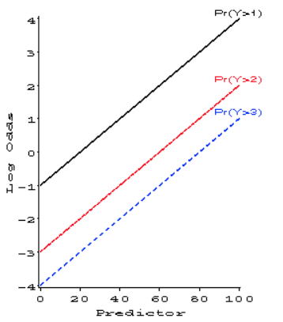

- Y-axis is $log[\frac{Pr(Y > j | X)}{1 - Pr(Y > j | X)}]$
- Effect of predictor (slope $\beta$) on $Y$ is the same for all $Y$

**What if non-PO?**

- The true lines would not be parallel.
- The PO model $\hat{\beta}$ still has a meaningful interpretation: the *average* $\beta$ across all lines: the average effect of $X$ on $Y$

https://www.datavis.ca/courses/grcat/grc6.html

## Diabetes example

```r
fit <- rms::orm(
    formula = HbA1c ~ diabetes,
    data = nhgh
    );
odds.ratios <- exp(coef(fit));
ci <- exp(confint(fit));

round(odds.ratios['diabetes=Yes'], 1);
```

```
diabetes=Yes
        21.4
```

```r
round(ci['diabetes=Yes',], 1);
```

```
 2.5 % 97.5 %
  18.3   24.9
```

Diabetes patients have 21.4 times greater odds of having higher HbA1c compared to undiagnosed patients.

## c-index for PO model

- Recall $c = Pr (Y_2 > Y_1)$ is an effect size for Wilcoxon test
- You can approximate the c-index from the PO odds ratio<sup>1</sup>:

$$\begin{equation}
c = \frac{\text{OR}^{0.6453}}{1 + \text{OR}^{0.6453}}
\end{equation}$$

- For our example: $c = \frac{21.4^{0.6453}}{1 + 21.4^{0.6453}} = 0.878$ which is close to the c-index from Wilcoxon test (0.86)

<sup>1</sup>https://www.fharrell.com/post/powilcoxon/

## Other effect sizes for PO model

Besides the odds ratio and c-index, PO also supports several other important estimators:

- Quantiles (*e.g.* 25th, median, 75th) - see `rms::Quantile.orm`
  - Difference in quantiles between groups
- Mean - see `rms::Mean`
- $Pr(Y > y | X)$ - “exceedance probability”
  - Diff. in exceedance probabilities btwn groups

## Simulation study to assess robustness of PO model

- Compare the 2-sample t-test, wilcoxon test, and PO model for testing difference in HbA1c between diabetes and undiagnosed patients.
- **Goal**: determine which methods control false-positive-rate
- **Approach**:
1. Randomly sample 200 patients from `nhgh` diabetes dataset
2. Randomly permute the group labels (diabetes *vs.* undiagnosed) to create a dataset where $H_0$ is true
3. Record whether each test’s p value is less than $\alpha = 0.05$
4. Repeat steps 1-3 10,000 times
5. Calculate FPR as the proportion of datasets where $p < \alpha$
6. A method controls the FPR iff FPR $\le \alpha$

## PO model is more robust than t-test

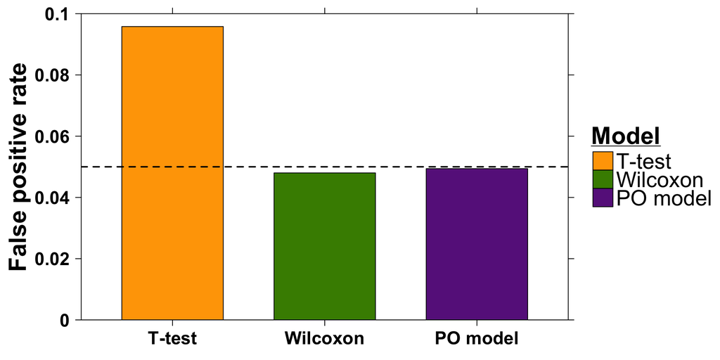

## Extensions

- [Longitudinal PO model](https://www.fharrell.com/post/rpo/#longitudinal-ordinal-models)
- [Power and sample size calculations](https://www.fharrell.com/post/rpo/#clinical-trial-design-resources)
- [Bayesian PO model](https://hbiostat.org/bbr/nonpar.html#bayesian-proportional-odds-model)

## Limitations

1. Proportional odds assumption

> …violations of the proportional odds assumption usually do not prevent the PO model from providing a reasonable treatment effect assessment. - [Violation of Proportional Odds is Not Fatal](https://www.fharrell.com/post/po/)
- If you only have 1 predictor the PO model will still control the FPR since PO assumption is guaranteed under $H_0$

Simulations show robustness of PO model under non-PO:

- [1 predictor](https://www.fharrell.com/post/powilcoxon/#simulation)
- [2 predictors](https://www.fharrell.com/post/impactpo/#simulation-study-of-effect-of-adjusting-for-a-highly-non-po-covariate)

[Resources for assessing impact of PO assumption](https://www.fharrell.com/post/impactpo/)

2. Sample size for continuous outcomes
- For discrete outcomes, large sample size is totally fine
- For continuous outcomes, `rms::orm` claims to efficiently handle “over 6000 distinct values” - I haven’t tested on larger than this.
3. Assumes linear and additive effects by default
- You can manually investigate adding non-linear or interaction terms
- It would be interesting to develop a MARS<sup>1</sup> version of PO model to automate this

1. https://en.wikipedia.org/wiki/Multivariate_adaptive_regression_spline

## Summary

- Proportional Odds model extends the Wilcoxon rank sum test to adjust for covariates
- [“If You Like the Wilcoxon test You Must Like the Proportional Odds Model”](https://www.fharrell.com/post/wpo/)
- Biological data are often non-normally distributed and contain outliers. PO model is a robust choice here compared to t-tests/linear regression.
- PO model estimates an odds ratio (odds of having a larger value of $Y$ given a 1 unit increase in $X$), but can also estimate c-index, quantiles, means
- Some simulation studies show robustness to non-PO, but more research needed here

## References

#### Intro to PO model:

- https://www.fharrell.com/post/rpo/
- French, Benjamin, and Matthew S. Shotwell. “Regression models for ordinal outcomes.” Jama 328.8 (2022): 772-773.

#### Wilcoxon test:

- https://hbiostat.org/bbr/nonpar#two-sample-test-wilcoxonmannwhitney
- [Equivalence of Wilcoxon Statistic and Proportional Odds Model](https://www.fharrell.com/post/powilcoxon/)
- If You Like the Wilcoxon Test You Must Like the Proportional Odds Model

#### PO model for continuous outcome:

- Liu, Qi, et al. “Modeling continuous response variables using ordinal regression.” Statistics in medicine 36.27 (2017): 4316-4335.
- https://hbiostat.org/rmsc/cony

#### Other refs in presentation:

Fay, Michael P, and Yaakov Malinovsky. 2018. “Confidence Intervals of the Mann-Whitney Parameter That Are Compatible with the Wilcoxon-Mann-Whitney Test.” *Statistics in Medicine* 37 (27): 3991–4006.

Li, Yumei, Xinzhou Ge, Fanglue Peng, Wei Li, and Jingyi Jessica Li. 2022. “Exaggerated False Positives by Popular Differential Expression Methods When Analyzing Human Population Samples.” *Genome Biology* 23 (1): 79.